# RT data analysis

- Show All Code
- Hide All Code
- View Source

Load in the data for all cell lines and parameterise

Authors

Nicholas Harbour

Markus Owen

Published

August 19, 2024, 14:22:00

Modified

August 19, 2024, 14:21:37

# 1 Import packages

```python
import numpy as np
import matplotlib.pyplot as plt
import pandas as pd
import scipy.stats as stats
from scipy.stats import lognorm
import matplotlib.colors as mcolors
from scipy.optimize import curve_fit
```

Import functions

```python
import gsc_model_functions as gmf
```

# 2 Load in the data

```python
rt_df = pd.read_csv("Data/RAW DATA- RT.csv")
rt_df.head()
```

|  | cline | rep | group | Exp | dose | ncells | ncolonies |
| --- | --- | --- | --- | --- | --- | --- | --- |
| 0 | GBM1a | 1 | CTRL | r01 | 0 | 200 | 41 |
| 1 | GBM1a | 1 | CTRL | r02 | 0 | 200 | 49 |
| 2 | GBM1a | 1 | CTRL | r03 | 0 | 200 | 41 |
| 3 | GBM1a | 1 | CTRL | r04 | 0 | 200 | 43 |
| 4 | GBM1a | 1 | CTRL | r05 | 0 | 200 | 47 |

This is the raw data and does not have plating effecinecy (pe) which is given by ncolonies/ncells, so lets add this column

```python
rt_df["pe"] =rt_df["ncolonies"]/ rt_df["ncells"]
rt_df.head()
```

|  | cline | rep | group | Exp | dose | ncells | ncolonies | pe |
| --- | --- | --- | --- | --- | --- | --- | --- | --- |
| 0 | GBM1a | 1 | CTRL | r01 | 0 | 200 | 41 | 0.205 |
| 1 | GBM1a | 1 | CTRL | r02 | 0 | 200 | 49 | 0.245 |
| 2 | GBM1a | 1 | CTRL | r03 | 0 | 200 | 41 | 0.205 |
| 3 | GBM1a | 1 | CTRL | r04 | 0 | 200 | 43 | 0.215 |
| 4 | GBM1a | 1 | CTRL | r05 | 0 | 200 | 47 | 0.235 |

identify the cell lines we have

```python
clines = rt_df["cline"].unique()
print("Cell lines")
print(clines)
```

```
Cell lines
['GBM1a' 'GBM965' 'U87' 'GBM626' 'QNS120' 'GBM549' 'QNS108' 'GBM640'
 'QNS657' 'QNS522b' 'QNS712' 'QNS166' 'QNS315' 'GBM963' 'QNS140' 'QNS679']
```

# 3 Normalise the data

We normalise the data: - Only inclide up to dose 6 Gy - Only include replicates that have measurement at 0,2,4,6 Gy - Normalise by rep, group (by survival at dose 0).

```python
# filter out doses above 6Gy
rt_df = rt_df[rt_df["dose"] <= 6]

# initialisea column with all 0s
rt_df["norm_pe"] = 0


for cline in clines:

    # get a specific cell line
    #test = rt_df[rt_df["cline"] == cline]


    # keep only replicates that have measurements at 0,2,4, (and/or 5),6 Gy
    keep_reps = []
    for rep in rt_df[rt_df["cline"] == cline]["rep"].unique():
        if len(rt_df[(rt_df["cline"] == cline) & (rt_df["rep"] == rep) ]["dose"].unique()) >= 4:
            keep_reps.append(rep)


    rt_df[(rt_df["cline"] == cline)] = rt_df[(rt_df["cline"] == cline) & (rt_df['rep'].isin(keep_reps))]


    # extract unique groups for each cline
    groups = rt_df[rt_df["cline"] == cline]["group"].unique()

    for rep in rt_df[rt_df["cline"] == cline]["rep"].unique():
        for group in groups:
            # Filter the DataFrame for the current replicate and group
            temp = rt_df[(rt_df["cline"] == cline) & (rt_df["rep"] == rep) & (rt_df["group"] == group)]

            # Calculate the mean of 'pe' at dose 0 for normalization
            mean_pe_dose_0 = temp[temp["dose"] == 0]["pe"].mean()

            # Normalize 'pe' and update 'norm_pe' in the original DataFrame
            rt_df.loc[(rt_df["rep"] == rep) & (rt_df["group"] == group) & (rt_df["cline"] == cline) , "norm_pe"] = temp["pe"] / mean_pe_dose_0


rt_df = rt_df.dropna() # remove Nans
print(rt_df)

# Save the updated DataFrame to a new file if needed
rt_df.to_csv('Data/rt_df.csv', index=False)
```

```
       cline  rep     group  Exp  dose  ncells  ncolonies      pe   norm_pe
0      GBM1a  1.0      CTRL  r01   0.0   200.0       41.0  0.2050  0.884892
1      GBM1a  1.0      CTRL  r02   0.0   200.0       49.0  0.2450  1.057554
2      GBM1a  1.0      CTRL  r03   0.0   200.0       41.0  0.2050  0.884892
3      GBM1a  1.0      CTRL  r04   0.0   200.0       43.0  0.2150  0.928058
4      GBM1a  1.0      CTRL  r05   0.0   200.0       47.0  0.2350  1.014388
...      ...  ...       ...  ...   ...     ...        ...     ...       ...
3123  GBM626  3.0  MSC-BMP4  r06   0.0  1250.0        5.0  0.0040  0.735294
3124  GBM626  3.0  MSC-BMP4  r07   0.0  1250.0        4.0  0.0032  0.588235
3125  GBM626  3.0  MSC-BMP4  r08   0.0  1250.0        8.0  0.0064  1.176471
3126  GBM626  3.0  MSC-BMP4  r09   0.0  1250.0        8.0  0.0064  1.176471
3127  GBM626  3.0  MSC-BMP4  r10   0.0  1250.0       11.0  0.0088  1.617647

[2853 rows x 9 columns]
```

# 4 plot survival (Raw data)

We will plot the survival for the cell lines which we have doubling times for as well

## 4.1 GBM1a (Male Primary)

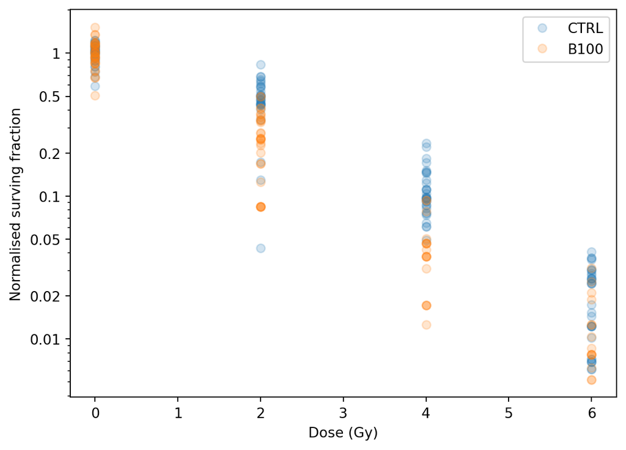

```python
cline = "GBM1a"
plt.plot(rt_df[(rt_df["cline"] == cline) & (rt_df["group"] == "CTRL")]["dose"],rt_df[(rt_df["cline"]== cline) & (rt_df["group"] == "CTRL")]["norm_pe"] , 'o',alpha = 0.2)
plt.plot(rt_df[(rt_df["cline"] == cline) & (rt_df["group"] == "BMP4")]["dose"],rt_df[(rt_df["cline"]== cline) & (rt_df["group"] == "BMP4")]["norm_pe"] , 'o',alpha = 0.2)

plt.legend(["CTRL", "B100"])
plt.xlabel("Dose (Gy)")
plt.ylabel("Normalised surving fraction")
plt.yscale('log')
ticks = [0.01,0.02,0.05,0.1,0.2,0.5,1]
ticks_str = list(map(str, ticks)) # Convert each number to a string
plt.yticks(ticks, ticks_str)
plt.show()
```

## 4.2 QNS120 (Male Primary)

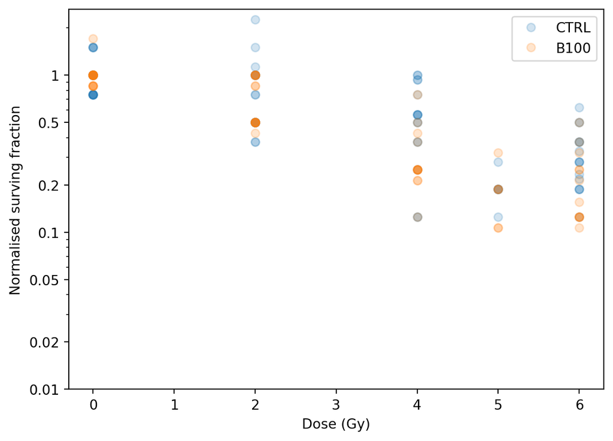

```python
cline = "QNS120"
plt.plot(rt_df[(rt_df["cline"] == cline) & (rt_df["group"] == "CTRL")]["dose"],rt_df[(rt_df["cline"]== cline) & (rt_df["group"] == "CTRL")]["norm_pe"] , 'o',alpha = 0.2)
plt.plot(rt_df[(rt_df["cline"] == cline) & (rt_df["group"] == "BMP4")]["dose"],rt_df[(rt_df["cline"]== cline) & (rt_df["group"] == "BMP4")]["norm_pe"] , 'o',alpha = 0.2)

plt.legend(["CTRL", "B100"])
plt.xlabel("Dose (Gy)")
plt.ylabel("Normalised surving fraction")
plt.yscale('log')
ticks = [0.01,0.02,0.05,0.1,0.2,0.5,1]
ticks_str = list(map(str, ticks)) # Convert each number to a string
plt.yticks(ticks, ticks_str)
plt.show()
```

## 4.3 QNS108 (Male Primary)

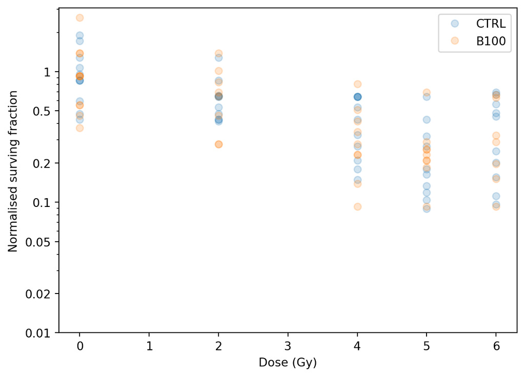

```python
cline = "QNS108"
plt.plot(rt_df[(rt_df["cline"] == cline) & (rt_df["group"] == "CTRL")]["dose"],rt_df[(rt_df["cline"]== cline) & (rt_df["group"] == "CTRL")]["norm_pe"] , 'o',alpha = 0.2)
plt.plot(rt_df[(rt_df["cline"] == cline) & (rt_df["group"] == "BMP4")]["dose"],rt_df[(rt_df["cline"]== cline) & (rt_df["group"] == "BMP4")]["norm_pe"] , 'o',alpha = 0.2)

plt.legend(["CTRL", "B100"])
plt.xlabel("Dose (Gy)")
plt.ylabel("Normalised surving fraction")
plt.yscale('log')
ticks = [0.01,0.02,0.05,0.1,0.2,0.5,1]
ticks_str = list(map(str, ticks)) # Convert each number to a string
plt.yticks(ticks, ticks_str)
plt.show()
```

## 4.4 QNS315 (Female Primary)

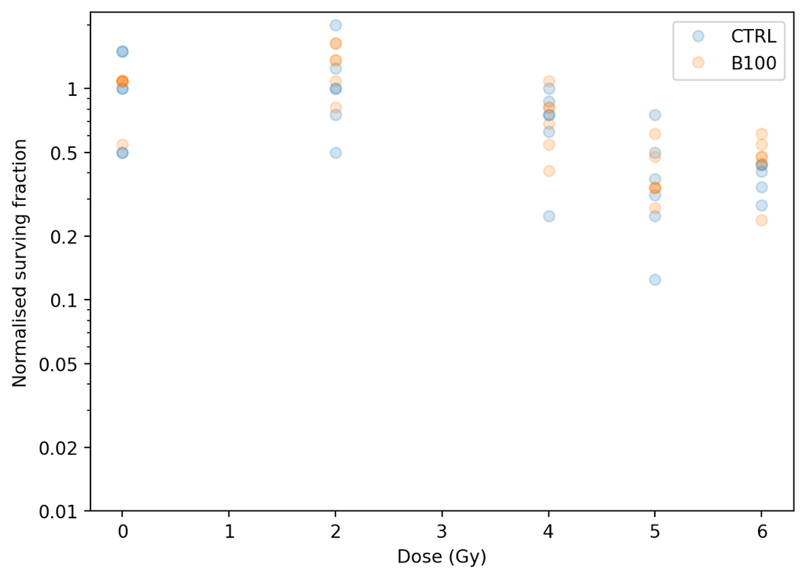

```python
cline = "QNS315"
plt.plot(rt_df[(rt_df["cline"] == cline) & (rt_df["group"] == "CTRL")]["dose"],rt_df[(rt_df["cline"]== cline) & (rt_df["group"] == "CTRL")]["norm_pe"] , 'o',alpha = 0.2)
plt.plot(rt_df[(rt_df["cline"] == cline) & (rt_df["group"] == "BMP4")]["dose"],rt_df[(rt_df["cline"]== cline) & (rt_df["group"] == "BMP4")]["norm_pe"] , 'o',alpha = 0.2)

plt.legend(["CTRL", "B100"])
plt.xlabel("Dose (Gy)")
plt.ylabel("Normalised surving fraction")
plt.yscale('log')
ticks = [0.01,0.02,0.05,0.1,0.2,0.5,1]
ticks_str = list(map(str, ticks)) # Convert each number to a string
plt.yticks(ticks, ticks_str)
plt.show()
```

## 4.5 QNS522b

QNS522 is a male primary (not sure if this is the same person?)

[figure not shown]

```python
cline = "QNS522b "
plt.plot(rt_df[(rt_df["cline"] == cline) & (rt_df["group"] == "CTRL")]["dose"],rt_df[(rt_df["cline"]== cline) & (rt_df["group"] == "CTRL")]["norm_pe"] , 'o',alpha = 0.2)
plt.plot(rt_df[(rt_df["cline"] == cline) & (rt_df["group"] == "BMP4")]["dose"],rt_df[(rt_df["cline"]== cline) & (rt_df["group"] == "BMP4")]["norm_pe"] , 'o',alpha = 0.2)

plt.legend(["CTRL", "B100"])
plt.xlabel("Dose (Gy)")
plt.ylabel("Normalised surving fraction")
plt.yscale('log')
ticks = [0.01,0.02,0.05,0.1,0.2,0.5,1]
ticks_str = list(map(str, ticks)) # Convert each number to a string
plt.yticks(ticks, ticks_str)
plt.show()
```

## 4.6 QNS657 (Female primary)

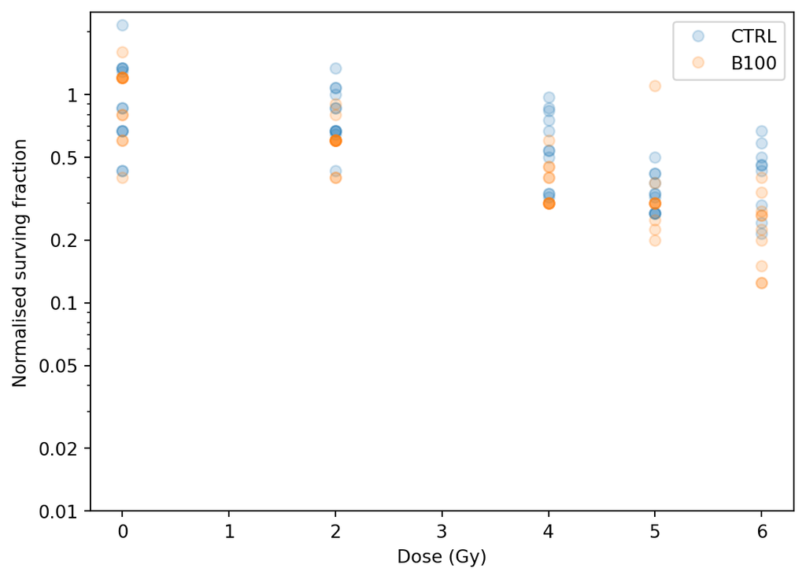

```python
cline = "QNS657"
plt.plot(rt_df[(rt_df["cline"] == cline) & (rt_df["group"] == "CTRL")]["dose"],rt_df[(rt_df["cline"]== cline) & (rt_df["group"] == "CTRL")]["norm_pe"] , 'o',alpha = 0.2)
plt.plot(rt_df[(rt_df["cline"] == cline) & (rt_df["group"] == "BMP4")]["dose"],rt_df[(rt_df["cline"]== cline) & (rt_df["group"] == "BMP4")]["norm_pe"] , 'o',alpha = 0.2)

plt.legend(["CTRL", "B100"])
plt.xlabel("Dose (Gy)")
plt.ylabel("Normalised surving fraction")
plt.yscale('log')
ticks = [0.01,0.02,0.05,0.1,0.2,0.5,1]
ticks_str = list(map(str, ticks)) # Convert each number to a string
plt.yticks(ticks, ticks_str)
plt.show()
```

# 5 Plot survival LQ model fits

## 5.1 GBM1a (Male primary)

```python
cline = "GBM1a"

# Define the linear-quadratic model
def LQ_model(dose, alpha, beta):
    return np.exp(-alpha * dose - beta * dose**2)

def LQ_model_fixed_ratio(dose, alpha):
    beta = alpha / 10
    return np.exp(-alpha * dose - beta * dose**2)

# Fit the model to the data CTRL case
popt_ctrl, pcov_ctrl = curve_fit(LQ_model, rt_df[(rt_df["cline"] == cline) & (rt_df["group"] == "CTRL")]["dose"], rt_df[(rt_df["cline"]== cline) & (rt_df["group"] == "CTRL")]["norm_pe"],bounds=([0, 0], [np.inf, np.inf]))

popt_ctrl_fixed, pcov_ctrl_fixed = curve_fit(LQ_model_fixed_ratio, rt_df[(rt_df["cline"] == cline) & (rt_df["group"] == "CTRL")]["dose"], rt_df[(rt_df["cline"]== cline) & (rt_df["group"] == "CTRL")]["norm_pe"],bounds=([0], [np.inf]))

# Fit the model to the data BMP4 case
popt_BMP4, pcov_BMP4 = curve_fit(LQ_model, rt_df[(rt_df["cline"] == cline) & (rt_df["group"] == "BMP4")]["dose"], rt_df[(rt_df["cline"]== cline) & (rt_df["group"] == "BMP4")]["norm_pe"],bounds=([0, 0], [np.inf, np.inf]))

popt_BMP4_fixed, pcov_BMP4_fixed = curve_fit(LQ_model_fixed_ratio, rt_df[(rt_df["cline"] == cline) & (rt_df["group"] == "BMP4")]["dose"], rt_df[(rt_df["cline"]== cline) & (rt_df["group"] == "BMP4")]["norm_pe"],bounds=([0], [np.inf]))

# Extract the fitted parameters CTRL case
alpha_CTRL, beta_CTRL = popt_ctrl
print(f"Fitted parameters for CTRL case: alpha = {alpha_CTRL}, beta = {beta_CTRL}")
print(f"alpha/beta = {alpha_CTRL/beta_CTRL}")

alpha_CTRL_fixed= popt_ctrl_fixed
print(f"Fitted parameters for CTRL case ith alpha/beta =10 fixed: alpha = {alpha_CTRL_fixed}, beta = {alpha_CTRL_fixed/10}")

# Extract the fitted parameters BMP4 case
alpha_BMP4, beta_BMP4 = popt_BMP4
print(f"Fitted parameters for BMP4 case: alpha = {alpha_BMP4}, beta = {beta_BMP4}")
print(f"alpha/beta = {alpha_BMP4/beta_BMP4}")

alpha_BMP4_fixed= popt_BMP4_fixed
print(f"Fitted parameters for BMP4 case ith alpha/beta =10 fixed: alpha = {alpha_BMP4_fixed}, beta = {alpha_BMP4_fixed/10}")
```

```
Fitted parameters for CTRL case: alpha = 0.1831989172651574, beta = 0.08989100165103327
alpha/beta = 2.038011746452172
Fitted parameters for CTRL case ith alpha/beta =10 fixed: alpha = [0.33841873], beta = [0.03384187]
Fitted parameters for BMP4 case: alpha = 0.5645030774022799, beta = 0.05115297310614947
alpha/beta = 11.035586851048876
Fitted parameters for BMP4 case ith alpha/beta =10 fixed: alpha = [0.5550979], beta = [0.05550979]
```

Plot the results of the LQ fit

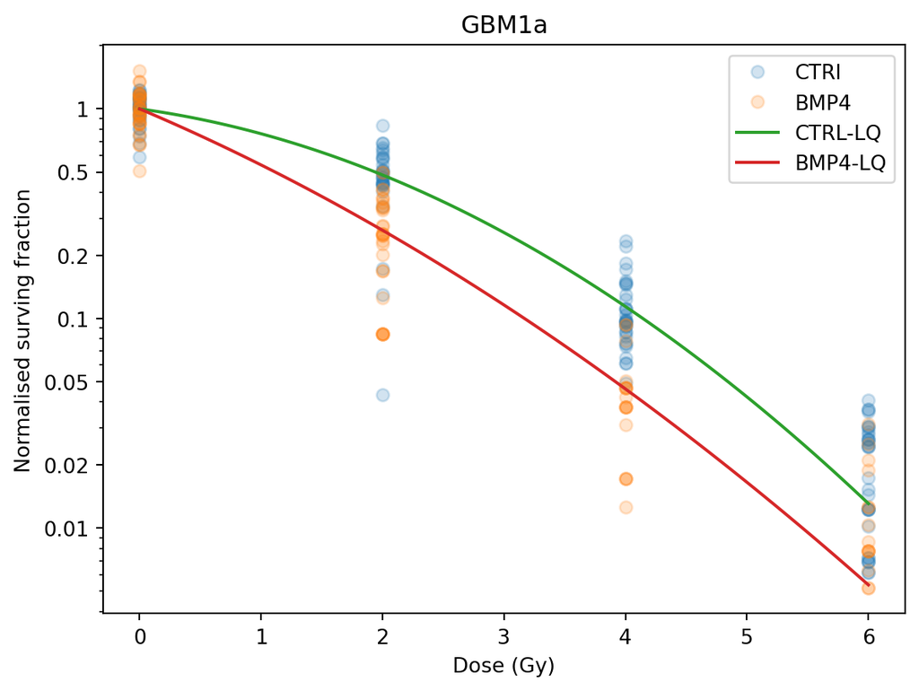

```python
plt.plot(rt_df[(rt_df["cline"] == cline) & (rt_df["group"] == "CTRL")]["dose"],rt_df[(rt_df["cline"]== cline) & (rt_df["group"] == "CTRL")]["norm_pe"] , 'o',alpha = 0.2)
plt.plot(rt_df[(rt_df["cline"] == cline) & (rt_df["group"] == "BMP4")]["dose"],rt_df[(rt_df["cline"]== cline) & (rt_df["group"] == "BMP4")]["norm_pe"] , 'o',alpha = 0.2)

doses= np.linspace(0,6,101)
plt.plot(doses,LQ_model(doses,alpha_CTRL,beta_CTRL))
plt.plot(doses,LQ_model(doses,alpha_BMP4,beta_BMP4))

plt.legend(["CTRl", "BMP4", "CTRL-LQ", "BMP4-LQ"])
plt.xlabel("Dose (Gy)")
plt.ylabel("Normalised surving fraction")
plt.yscale('log')
ticks = [0.01,0.02,0.05,0.1,0.2,0.5,1]
ticks_str = list(map(str, ticks)) # Convert each number to a string
plt.yticks(ticks, ticks_str)
plt.title(f"{cline}")

plt.show()
```

With alpha / beta fixed to 10

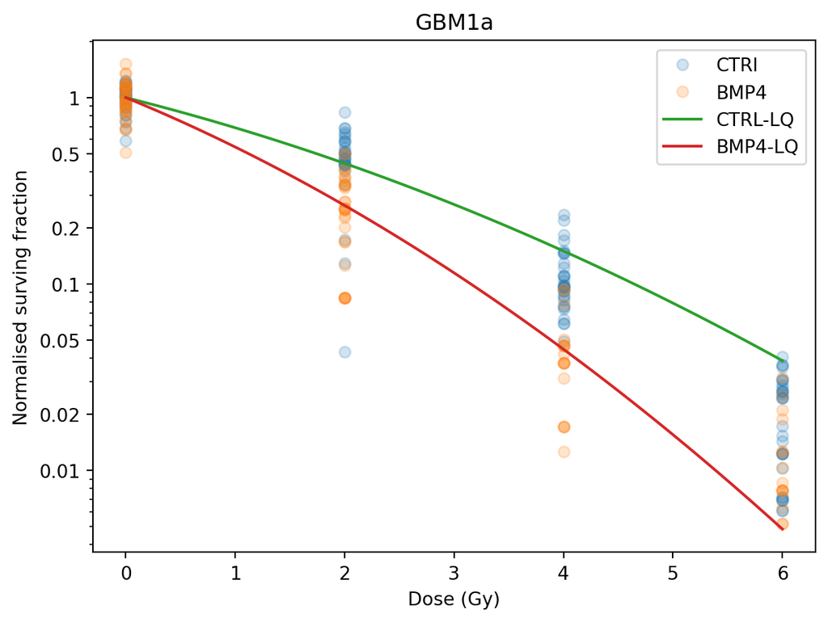

```python
plt.plot(rt_df[(rt_df["cline"] == cline) & (rt_df["group"] == "CTRL")]["dose"],rt_df[(rt_df["cline"]== cline) & (rt_df["group"] == "CTRL")]["norm_pe"] , 'o',alpha = 0.2)
plt.plot(rt_df[(rt_df["cline"] == cline) & (rt_df["group"] == "BMP4")]["dose"],rt_df[(rt_df["cline"]== cline) & (rt_df["group"] == "BMP4")]["norm_pe"] , 'o',alpha = 0.2)

doses= np.linspace(0,6,101)
plt.plot(doses,LQ_model_fixed_ratio(doses,alpha_CTRL_fixed))
plt.plot(doses,LQ_model_fixed_ratio(doses,alpha_BMP4_fixed))

plt.legend(["CTRl", "BMP4", "CTRL-LQ", "BMP4-LQ"])
plt.xlabel("Dose (Gy)")
plt.ylabel("Normalised surving fraction")
plt.yscale('log')
ticks = [0.01,0.02,0.05,0.1,0.2,0.5,1]
ticks_str = list(map(str, ticks)) # Convert each number to a string
plt.yticks(ticks, ticks_str)
plt.title(f"{cline}")

plt.show()
```

## 5.2 QNS120 (Male primary)

```python
cline = "QNS120"

# Fit the model to the data CTRL case
popt_ctrl, pcov_ctrl = curve_fit(LQ_model, rt_df[(rt_df["cline"] == cline) & (rt_df["group"] == "CTRL")]["dose"], rt_df[(rt_df["cline"]== cline) & (rt_df["group"] == "CTRL")]["norm_pe"],bounds=([0, 0], [np.inf, np.inf]))

popt_ctrl_fixed, pcov_ctrl_fixed = curve_fit(LQ_model_fixed_ratio, rt_df[(rt_df["cline"] == cline) & (rt_df["group"] == "CTRL")]["dose"], rt_df[(rt_df["cline"]== cline) & (rt_df["group"] == "CTRL")]["norm_pe"],bounds=([0], [np.inf]))

# Fit the model to the data BMP4 case
popt_BMP4, pcov_BMP4 = curve_fit(LQ_model, rt_df[(rt_df["cline"] == cline) & (rt_df["group"] == "BMP4")]["dose"], rt_df[(rt_df["cline"]== cline) & (rt_df["group"] == "BMP4")]["norm_pe"],bounds=([0, 0], [np.inf, np.inf]))

popt_BMP4_fixed, pcov_BMP4_fixed = curve_fit(LQ_model_fixed_ratio, rt_df[(rt_df["cline"] == cline) & (rt_df["group"] == "BMP4")]["dose"], rt_df[(rt_df["cline"]== cline) & (rt_df["group"] == "BMP4")]["norm_pe"],bounds=([0], [np.inf]))

# Extract the fitted parameters CTRL case
alpha_CTRL, beta_CTRL = popt_ctrl
print(f"Fitted parameters for CTRL case: alpha = {alpha_CTRL}, beta = {beta_CTRL}")
print(f"alpha/beta = {alpha_CTRL/beta_CTRL}")

alpha_CTRL_fixed= popt_ctrl_fixed
print(f"Fitted parameters for CTRL case ith alpha/beta =10 fixed: alpha = {alpha_CTRL_fixed}, beta = {alpha_CTRL_fixed/10}")

# Extract the fitted parameters BMP4 case
alpha_BMP4, beta_BMP4 = popt_BMP4
print(f"Fitted parameters for BMP4 case: alpha = {alpha_BMP4}, beta = {beta_BMP4}")
print(f"alpha/beta = {alpha_BMP4/beta_BMP4}")

alpha_BMP4_fixed= popt_BMP4_fixed
print(f"Fitted parameters for BMP4 case ith alpha/beta =10 fixed: alpha = {alpha_BMP4_fixed}, beta = {alpha_BMP4_fixed/10}")
```

```
Fitted parameters for CTRL case: alpha = 0.014037184418926985, beta = 0.03455851742606245
alpha/beta = 0.406185955429349
Fitted parameters for CTRL case ith alpha/beta =10 fixed: alpha = [0.11569914], beta = [0.01156991]
Fitted parameters for BMP4 case: alpha = 0.12024891288101179, beta = 0.03279889761653553
alpha/beta = 3.6662486125871627
Fitted parameters for BMP4 case ith alpha/beta =10 fixed: alpha = [0.17710572], beta = [0.01771057]
```

Plot the results of the LQ fit

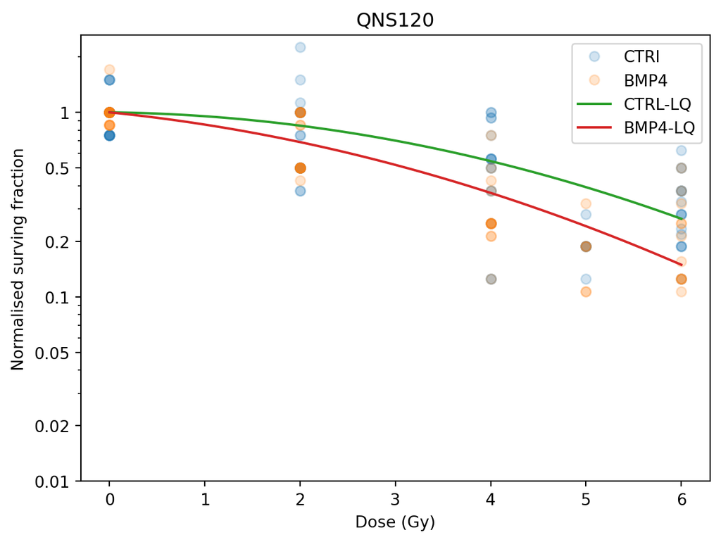

```python
plt.plot(rt_df[(rt_df["cline"] == cline) & (rt_df["group"] == "CTRL")]["dose"],rt_df[(rt_df["cline"]== cline) & (rt_df["group"] == "CTRL")]["norm_pe"] , 'o',alpha = 0.2)
plt.plot(rt_df[(rt_df["cline"] == cline) & (rt_df["group"] == "BMP4")]["dose"],rt_df[(rt_df["cline"]== cline) & (rt_df["group"] == "BMP4")]["norm_pe"] , 'o',alpha = 0.2)

doses= np.linspace(0,6,101)
plt.plot(doses,LQ_model(doses,alpha_CTRL,beta_CTRL))
plt.plot(doses,LQ_model(doses,alpha_BMP4,beta_BMP4))

plt.legend(["CTRl", "BMP4", "CTRL-LQ", "BMP4-LQ"])
plt.xlabel("Dose (Gy)")
plt.ylabel("Normalised surving fraction")
plt.yscale('log')
ticks = [0.01,0.02,0.05,0.1,0.2,0.5,1]
ticks_str = list(map(str, ticks)) # Convert each number to a string
plt.yticks(ticks, ticks_str)
plt.title(f"{cline}")

plt.show()
```

With alpha / beta fixed to 10

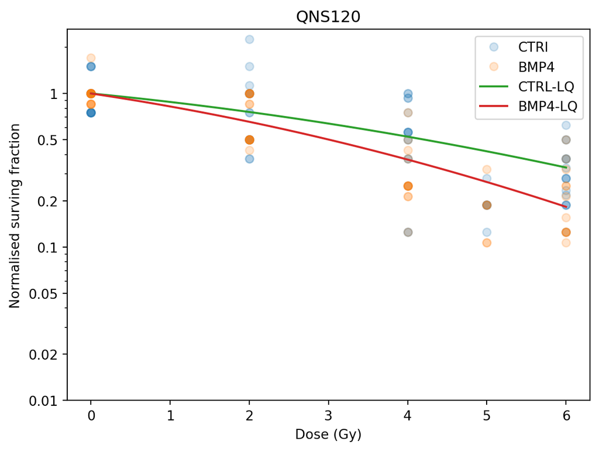

```python
plt.plot(rt_df[(rt_df["cline"] == cline) & (rt_df["group"] == "CTRL")]["dose"],rt_df[(rt_df["cline"]== cline) & (rt_df["group"] == "CTRL")]["norm_pe"] , 'o',alpha = 0.2)
plt.plot(rt_df[(rt_df["cline"] == cline) & (rt_df["group"] == "BMP4")]["dose"],rt_df[(rt_df["cline"]== cline) & (rt_df["group"] == "BMP4")]["norm_pe"] , 'o',alpha = 0.2)

doses= np.linspace(0,6,101)
plt.plot(doses,LQ_model_fixed_ratio(doses,alpha_CTRL_fixed))
plt.plot(doses,LQ_model_fixed_ratio(doses,alpha_BMP4_fixed))

plt.legend(["CTRl", "BMP4", "CTRL-LQ", "BMP4-LQ"])
plt.xlabel("Dose (Gy)")
plt.ylabel("Normalised surving fraction")
plt.yscale('log')
ticks = [0.01,0.02,0.05,0.1,0.2,0.5,1]
ticks_str = list(map(str, ticks)) # Convert each number to a string
plt.yticks(ticks, ticks_str)
plt.title(f"{cline}")

plt.show()
```

## 5.3 QNS108 (Male primary)

```python
cline = "QNS108"

# Fit the model to the data CTRL case
popt_ctrl, pcov_ctrl = curve_fit(LQ_model, rt_df[(rt_df["cline"] == cline) & (rt_df["group"] == "CTRL")]["dose"], rt_df[(rt_df["cline"]== cline) & (rt_df["group"] == "CTRL")]["norm_pe"],bounds=([0, 0], [np.inf, np.inf]))

popt_ctrl_fixed, pcov_ctrl_fixed = curve_fit(LQ_model_fixed_ratio, rt_df[(rt_df["cline"] == cline) & (rt_df["group"] == "CTRL")]["dose"], rt_df[(rt_df["cline"]== cline) & (rt_df["group"] == "CTRL")]["norm_pe"],bounds=([0], [np.inf]))

# Fit the model to the data BMP4 case
popt_BMP4, pcov_BMP4 = curve_fit(LQ_model, rt_df[(rt_df["cline"] == cline) & (rt_df["group"] == "BMP4")]["dose"], rt_df[(rt_df["cline"]== cline) & (rt_df["group"] == "BMP4")]["norm_pe"],bounds=([0, 0], [np.inf, np.inf]))

popt_BMP4_fixed, pcov_BMP4_fixed = curve_fit(LQ_model_fixed_ratio, rt_df[(rt_df["cline"] == cline) & (rt_df["group"] == "BMP4")]["dose"], rt_df[(rt_df["cline"]== cline) & (rt_df["group"] == "BMP4")]["norm_pe"],bounds=([0], [np.inf]))

# Extract the fitted parameters CTRL case
alpha_CTRL, beta_CTRL = popt_ctrl
print(f"Fitted parameters for CTRL case: alpha = {alpha_CTRL}, beta = {beta_CTRL}")
print(f"alpha/beta = {alpha_CTRL/beta_CTRL}")

alpha_CTRL_fixed= popt_ctrl_fixed
print(f"Fitted parameters for CTRL case ith alpha/beta =10 fixed: alpha = {alpha_CTRL_fixed}, beta = {alpha_CTRL_fixed/10}")

# Extract the fitted parameters BMP4 case
alpha_BMP4, beta_BMP4 = popt_BMP4
print(f"Fitted parameters for BMP4 case: alpha = {alpha_BMP4}, beta = {beta_BMP4}")
print(f"alpha/beta = {alpha_BMP4/beta_BMP4}")

alpha_BMP4_fixed= popt_BMP4_fixed
print(f"Fitted parameters for BMP4 case ith alpha/beta =10 fixed: alpha = {alpha_BMP4_fixed}, beta = {alpha_BMP4_fixed/10}")
```

```
Fitted parameters for CTRL case: alpha = 0.2175843971485717, beta = 8.702061194838374e-15
alpha/beta = 25003776953169.652
Fitted parameters for CTRL case ith alpha/beta =10 fixed: alpha = [0.15131625], beta = [0.01513163]
Fitted parameters for BMP4 case: alpha = 0.21769899970777878, beta = 0.002742752190634625
alpha/beta = 79.37246407135565
Fitted parameters for BMP4 case ith alpha/beta =10 fixed: alpha = [0.1607802], beta = [0.01607802]
```

Plot the results of the LQ fit

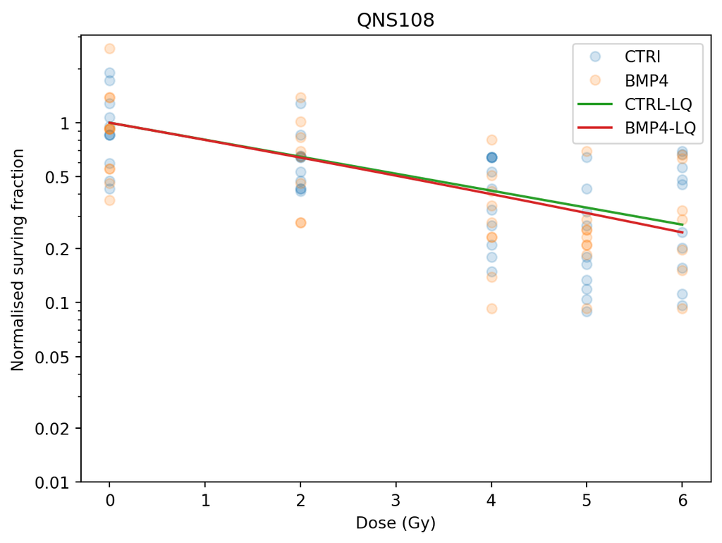

```python
plt.plot(rt_df[(rt_df["cline"] == cline) & (rt_df["group"] == "CTRL")]["dose"],rt_df[(rt_df["cline"]== cline) & (rt_df["group"] == "CTRL")]["norm_pe"] , 'o',alpha = 0.2)
plt.plot(rt_df[(rt_df["cline"] == cline) & (rt_df["group"] == "BMP4")]["dose"],rt_df[(rt_df["cline"]== cline) & (rt_df["group"] == "BMP4")]["norm_pe"] , 'o',alpha = 0.2)

doses= np.linspace(0,6,101)
plt.plot(doses,LQ_model(doses,alpha_CTRL,beta_CTRL))
plt.plot(doses,LQ_model(doses,alpha_BMP4,beta_BMP4))

plt.legend(["CTRl", "BMP4", "CTRL-LQ", "BMP4-LQ"])
plt.xlabel("Dose (Gy)")
plt.ylabel("Normalised surving fraction")
plt.yscale('log')
ticks = [0.01,0.02,0.05,0.1,0.2,0.5,1]
ticks_str = list(map(str, ticks)) # Convert each number to a string
plt.yticks(ticks, ticks_str)
plt.title(f"{cline}")

plt.show()
```

With alpha / beta fixed to 10

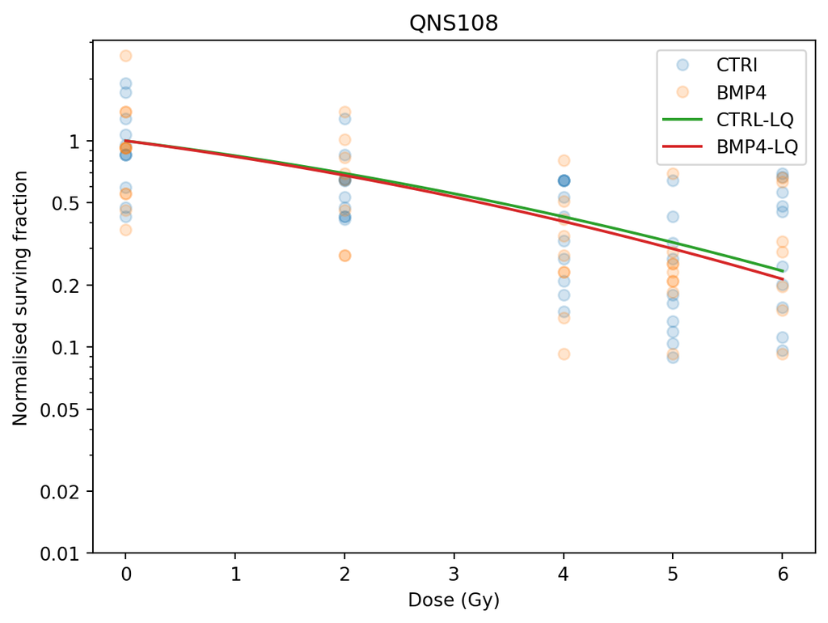

```python
plt.plot(rt_df[(rt_df["cline"] == cline) & (rt_df["group"] == "CTRL")]["dose"],rt_df[(rt_df["cline"]== cline) & (rt_df["group"] == "CTRL")]["norm_pe"] , 'o',alpha = 0.2)
plt.plot(rt_df[(rt_df["cline"] == cline) & (rt_df["group"] == "BMP4")]["dose"],rt_df[(rt_df["cline"]== cline) & (rt_df["group"] == "BMP4")]["norm_pe"] , 'o',alpha = 0.2)

doses= np.linspace(0,6,101)
plt.plot(doses,LQ_model_fixed_ratio(doses,alpha_CTRL_fixed))
plt.plot(doses,LQ_model_fixed_ratio(doses,alpha_BMP4_fixed))

plt.legend(["CTRl", "BMP4", "CTRL-LQ", "BMP4-LQ"])
plt.xlabel("Dose (Gy)")
plt.ylabel("Normalised surving fraction")
plt.yscale('log')
ticks = [0.01,0.02,0.05,0.1,0.2,0.5,1]
ticks_str = list(map(str, ticks)) # Convert each number to a string
plt.yticks(ticks, ticks_str)
plt.title(f"{cline}")

plt.show()
```

## 5.4 QNS315 (Female primary)

```python
cline = "QNS315"

# Fit the model to the data CTRL case
popt_ctrl, pcov_ctrl = curve_fit(LQ_model, rt_df[(rt_df["cline"] == cline) & (rt_df["group"] == "CTRL")]["dose"], rt_df[(rt_df["cline"]== cline) & (rt_df["group"] == "CTRL")]["norm_pe"],bounds=([0, 0], [np.inf, np.inf]))

popt_ctrl_fixed, pcov_ctrl_fixed = curve_fit(LQ_model_fixed_ratio, rt_df[(rt_df["cline"] == cline) & (rt_df["group"] == "CTRL")]["dose"], rt_df[(rt_df["cline"]== cline) & (rt_df["group"] == "CTRL")]["norm_pe"],bounds=([0], [np.inf]))

# Fit the model to the data BMP4 case
popt_BMP4, pcov_BMP4 = curve_fit(LQ_model, rt_df[(rt_df["cline"] == cline) & (rt_df["group"] == "BMP4")]["dose"], rt_df[(rt_df["cline"]== cline) & (rt_df["group"] == "BMP4")]["norm_pe"],bounds=([0, 0], [np.inf, np.inf]))

popt_BMP4_fixed, pcov_BMP4_fixed = curve_fit(LQ_model_fixed_ratio, rt_df[(rt_df["cline"] == cline) & (rt_df["group"] == "BMP4")]["dose"], rt_df[(rt_df["cline"]== cline) & (rt_df["group"] == "BMP4")]["norm_pe"],bounds=([0], [np.inf]))

# Extract the fitted parameters CTRL case
alpha_CTRL, beta_CTRL = popt_ctrl
print(f"Fitted parameters for CTRL case: alpha = {alpha_CTRL}, beta = {beta_CTRL}")
print(f"alpha/beta = {alpha_CTRL/beta_CTRL}")

alpha_CTRL_fixed= popt_ctrl_fixed
print(f"Fitted parameters for CTRL case ith alpha/beta =10 fixed: alpha = {alpha_CTRL_fixed}, beta = {alpha_CTRL_fixed/10}")

# Extract the fitted parameters BMP4 case
alpha_BMP4, beta_BMP4 = popt_BMP4
print(f"Fitted parameters for BMP4 case: alpha = {alpha_BMP4}, beta = {beta_BMP4}")
print(f"alpha/beta = {alpha_BMP4/beta_BMP4}")

alpha_BMP4_fixed= popt_BMP4_fixed
print(f"Fitted parameters for BMP4 case ith alpha/beta =10 fixed: alpha = {alpha_BMP4_fixed}, beta = {alpha_BMP4_fixed/10}")
```

```
Fitted parameters for CTRL case: alpha = 8.633812961320722e-15, beta = 0.027575866247915973
alpha/beta = 3.130930823242304e-13
Fitted parameters for CTRL case ith alpha/beta =10 fixed: alpha = [0.0841315], beta = [0.00841315]
Fitted parameters for BMP4 case: alpha = 6.639316331301948e-19, beta = 0.02299028499670563
alpha/beta = 2.887879089908334e-17
Fitted parameters for BMP4 case ith alpha/beta =10 fixed: alpha = [0.06889958], beta = [0.00688996]
```

Plot the results of the LQ fit

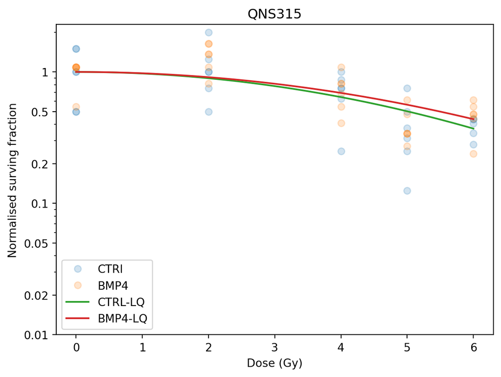

```python
plt.plot(rt_df[(rt_df["cline"] == cline) & (rt_df["group"] == "CTRL")]["dose"],rt_df[(rt_df["cline"]== cline) & (rt_df["group"] == "CTRL")]["norm_pe"] , 'o',alpha = 0.2)
plt.plot(rt_df[(rt_df["cline"] == cline) & (rt_df["group"] == "BMP4")]["dose"],rt_df[(rt_df["cline"]== cline) & (rt_df["group"] == "BMP4")]["norm_pe"] , 'o',alpha = 0.2)

doses= np.linspace(0,6,101)
plt.plot(doses,LQ_model(doses,alpha_CTRL,beta_CTRL))
plt.plot(doses,LQ_model(doses,alpha_BMP4,beta_BMP4))

plt.legend(["CTRl", "BMP4", "CTRL-LQ", "BMP4-LQ"])
plt.xlabel("Dose (Gy)")
plt.ylabel("Normalised surving fraction")
plt.yscale('log')
ticks = [0.01,0.02,0.05,0.1,0.2,0.5,1]
ticks_str = list(map(str, ticks)) # Convert each number to a string
plt.yticks(ticks, ticks_str)
plt.title(f"{cline}")

plt.show()
```

With alpha / beta fixed to 10

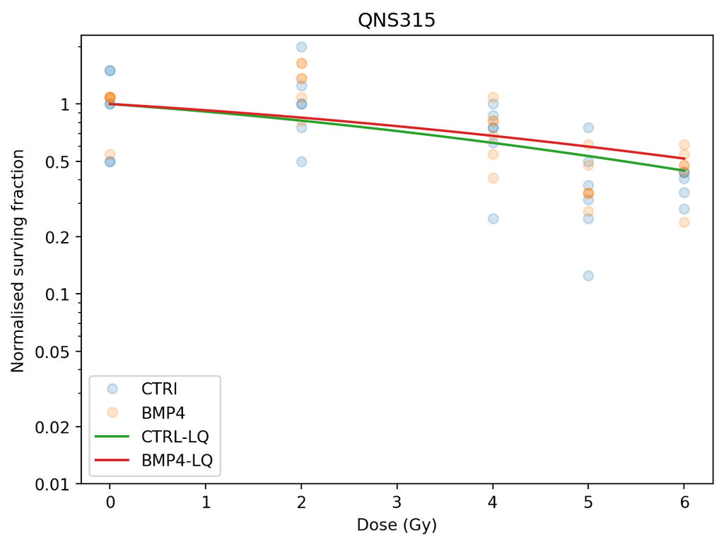

```python
plt.plot(rt_df[(rt_df["cline"] == cline) & (rt_df["group"] == "CTRL")]["dose"],rt_df[(rt_df["cline"]== cline) & (rt_df["group"] == "CTRL")]["norm_pe"] , 'o',alpha = 0.2)
plt.plot(rt_df[(rt_df["cline"] == cline) & (rt_df["group"] == "BMP4")]["dose"],rt_df[(rt_df["cline"]== cline) & (rt_df["group"] == "BMP4")]["norm_pe"] , 'o',alpha = 0.2)

doses= np.linspace(0,6,101)
plt.plot(doses,LQ_model_fixed_ratio(doses,alpha_CTRL_fixed))
plt.plot(doses,LQ_model_fixed_ratio(doses,alpha_BMP4_fixed))

plt.legend(["CTRl", "BMP4", "CTRL-LQ", "BMP4-LQ"])
plt.xlabel("Dose (Gy)")
plt.ylabel("Normalised surving fraction")
plt.yscale('log')
ticks = [0.01,0.02,0.05,0.1,0.2,0.5,1]
ticks_str = list(map(str, ticks)) # Convert each number to a string
plt.yticks(ticks, ticks_str)
plt.title(f"{cline}")

plt.show()
```

## 5.5 QNS657 (Female primary)

```python
cline = "QNS657"

# Fit the model to the data CTRL case
popt_ctrl, pcov_ctrl = curve_fit(LQ_model, rt_df[(rt_df["cline"] == cline) & (rt_df["group"] == "CTRL")]["dose"], rt_df[(rt_df["cline"]== cline) & (rt_df["group"] == "CTRL")]["norm_pe"],bounds=([0, 0], [np.inf, np.inf]))

popt_ctrl_fixed, pcov_ctrl_fixed = curve_fit(LQ_model_fixed_ratio, rt_df[(rt_df["cline"] == cline) & (rt_df["group"] == "CTRL")]["dose"], rt_df[(rt_df["cline"]== cline) & (rt_df["group"] == "CTRL")]["norm_pe"],bounds=([0], [np.inf]))

# Fit the model to the data BMP4 case
popt_BMP4, pcov_BMP4 = curve_fit(LQ_model, rt_df[(rt_df["cline"] == cline) & (rt_df["group"] == "BMP4")]["dose"], rt_df[(rt_df["cline"]== cline) & (rt_df["group"] == "BMP4")]["norm_pe"],bounds=([0, 0], [np.inf, np.inf]))

popt_BMP4_fixed, pcov_BMP4_fixed = curve_fit(LQ_model_fixed_ratio, rt_df[(rt_df["cline"] == cline) & (rt_df["group"] == "BMP4")]["dose"], rt_df[(rt_df["cline"]== cline) & (rt_df["group"] == "BMP4")]["norm_pe"],bounds=([0], [np.inf]))

# Extract the fitted parameters CTRL case
alpha_CTRL, beta_CTRL = popt_ctrl
print(f"Fitted parameters for CTRL case: alpha = {alpha_CTRL}, beta = {beta_CTRL}")
print(f"alpha/beta = {alpha_CTRL/beta_CTRL}")

alpha_CTRL_fixed= popt_ctrl_fixed
print(f"Fitted parameters for CTRL case ith alpha/beta =10 fixed: alpha = {alpha_CTRL_fixed}, beta = {alpha_CTRL_fixed/10}")

# Extract the fitted parameters BMP4 case
alpha_BMP4, beta_BMP4 = popt_BMP4
print(f"Fitted parameters for BMP4 case: alpha = {alpha_BMP4}, beta = {beta_BMP4}")
print(f"alpha/beta = {alpha_BMP4/beta_BMP4}")

alpha_BMP4_fixed= popt_BMP4_fixed
print(f"Fitted parameters for BMP4 case ith alpha/beta =10 fixed: alpha = {alpha_BMP4_fixed}, beta = {alpha_BMP4_fixed/10}")
```

```
Fitted parameters for CTRL case: alpha = 0.06416341211391817, beta = 0.019133324269813796
alpha/beta = 3.353490026568321
Fitted parameters for CTRL case ith alpha/beta =10 fixed: alpha = [0.10378728], beta = [0.01037873]
Fitted parameters for BMP4 case: alpha = 0.2328487210959747, beta = 4.934119629867336e-12
alpha/beta = 47191543489.64079
Fitted parameters for BMP4 case ith alpha/beta =10 fixed: alpha = [0.16258053], beta = [0.01625805]
```

Plot the results of the LQ fit

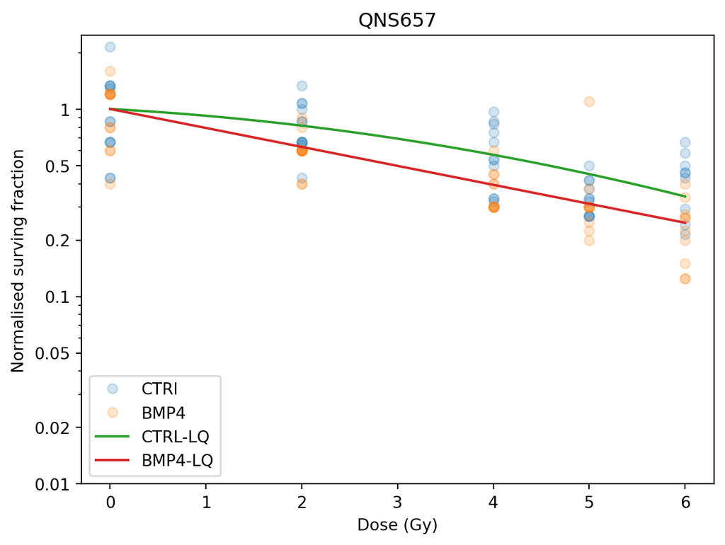

```python
plt.plot(rt_df[(rt_df["cline"] == cline) & (rt_df["group"] == "CTRL")]["dose"],rt_df[(rt_df["cline"]== cline) & (rt_df["group"] == "CTRL")]["norm_pe"] , 'o',alpha = 0.2)
plt.plot(rt_df[(rt_df["cline"] == cline) & (rt_df["group"] == "BMP4")]["dose"],rt_df[(rt_df["cline"]== cline) & (rt_df["group"] == "BMP4")]["norm_pe"] , 'o',alpha = 0.2)

doses= np.linspace(0,6,101)
plt.plot(doses,LQ_model(doses,alpha_CTRL,beta_CTRL))
plt.plot(doses,LQ_model(doses,alpha_BMP4,beta_BMP4))

plt.legend(["CTRl", "BMP4", "CTRL-LQ", "BMP4-LQ"])
plt.xlabel("Dose (Gy)")
plt.ylabel("Normalised surving fraction")
plt.yscale('log')
ticks = [0.01,0.02,0.05,0.1,0.2,0.5,1]
ticks_str = list(map(str, ticks)) # Convert each number to a string
plt.yticks(ticks, ticks_str)
plt.title(f"{cline}")

plt.show()
```

With alpha / beta fixed to 10

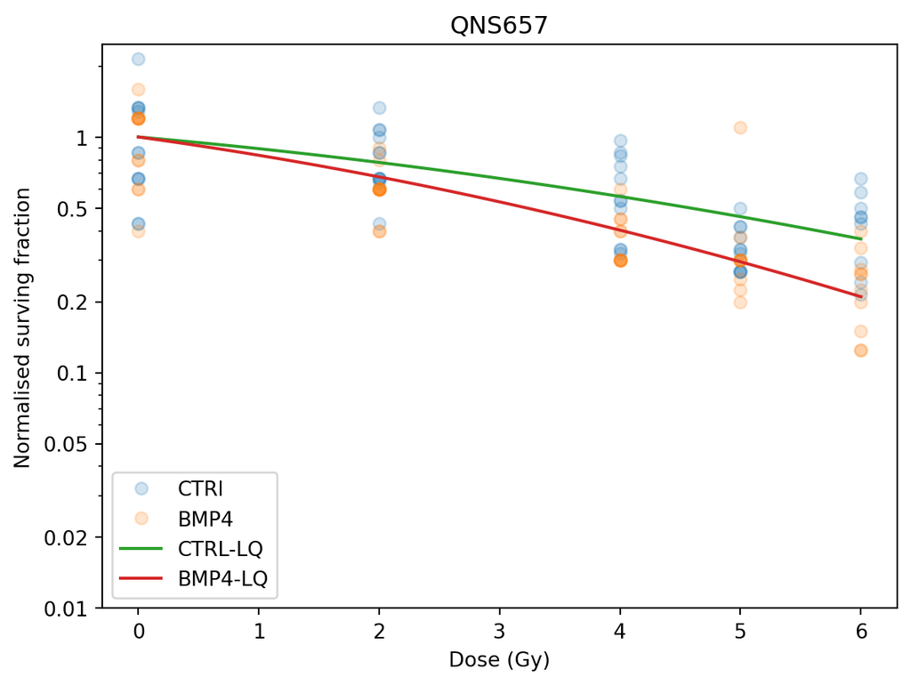

```python
plt.plot(rt_df[(rt_df["cline"] == cline) & (rt_df["group"] == "CTRL")]["dose"],rt_df[(rt_df["cline"]== cline) & (rt_df["group"] == "CTRL")]["norm_pe"] , 'o',alpha = 0.2)
plt.plot(rt_df[(rt_df["cline"] == cline) & (rt_df["group"] == "BMP4")]["dose"],rt_df[(rt_df["cline"]== cline) & (rt_df["group"] == "BMP4")]["norm_pe"] , 'o',alpha = 0.2)

doses= np.linspace(0,6,101)
plt.plot(doses,LQ_model_fixed_ratio(doses,alpha_CTRL_fixed))
plt.plot(doses,LQ_model_fixed_ratio(doses,alpha_BMP4_fixed))

plt.legend(["CTRl", "BMP4", "CTRL-LQ", "BMP4-LQ"])
plt.xlabel("Dose (Gy)")
plt.ylabel("Normalised surving fraction")
plt.yscale('log')
ticks = [0.01,0.02,0.05,0.1,0.2,0.5,1]
ticks_str = list(map(str, ticks)) # Convert each number to a string
plt.yticks(ticks, ticks_str)
plt.title(f"{cline}")

plt.show()
```

# 6 Fit DLQ

Now fit the Dual linear quadratic model to get an estimate of the fraction of GSCs

## 6.1 GBM1a (Male primary)

```
Fraction of GSC F = [0.57068221]
Fitted parameters for CTRL case: alpha = [2.45943847], beta = [0.24594385]
alpha/beta = [10.]
```

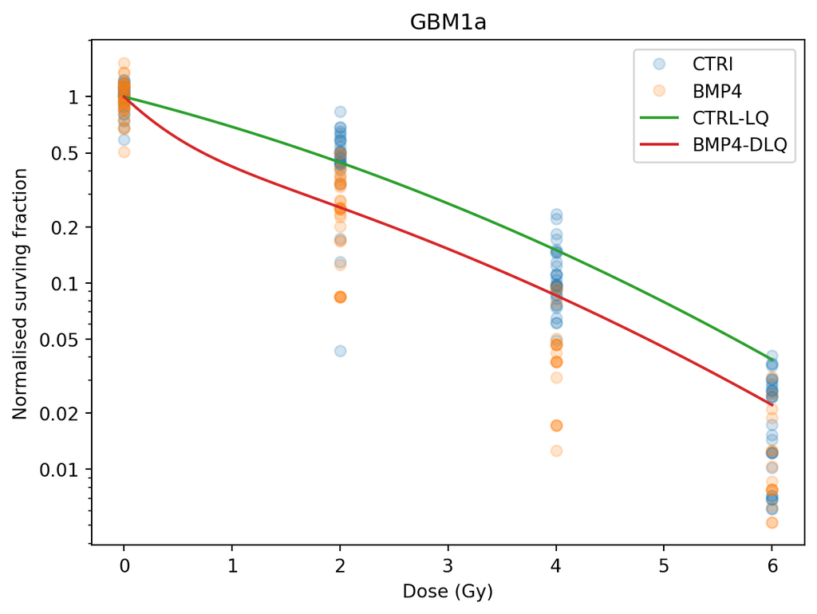

```python
cline = "GBM1a"

gamma = 0.1376 # Radioprotection of GSCs (doi:10.1158/0008-5472.CAN-12-3429)

# Fit the model to the data CTRL case
#popt_ctrl, pcov_ctrl = curve_fit(LQ_model, rt_df[(rt_df["cline"] == cline) & (rt_df["group"] == "CTRL")]["dose"], rt_df[(rt_df["cline"]== cline) & (rt_df["group"] == "CTRL")]["norm_pe"],bounds=([0, 0], [np.inf, np.inf]))

# Fit the model to the data CTRL case with alpha/beta fixed to 10
popt_ctrl_fixed, pcov_ctrl_fixed = curve_fit(LQ_model_fixed_ratio, rt_df[(rt_df["cline"] == cline) & (rt_df["group"] == "CTRL")]["dose"], rt_df[(rt_df["cline"]== cline) & (rt_df["group"] == "CTRL")]["norm_pe"],bounds=([0], [np.inf]))

# Extract the fitted parameters CTRL case
#alpha, beta = popt_ctrl
#alpha = alpha / gamma
#beta = beta / gamma

alpha = popt_ctrl_fixed
alpha = alpha / gamma
beta = alpha / 10

# Function to evaluate DLQ model
def DLQ_model(dose,F):

    return F*np.exp(gamma*(-alpha * dose - beta * dose**2)) + (1-F)*np.exp(-alpha * dose - beta * dose**2)


# Fit the model to the data BMP4 case to get an estimate of F
popt_BMP4, pcov_BMP4 = curve_fit(DLQ_model, rt_df[(rt_df["cline"] == cline) & (rt_df["group"] == "BMP4")]["dose"], rt_df[(rt_df["cline"]== cline) & (rt_df["group"] == "BMP4")]["norm_pe"],bounds=([0], [ 1]))

# Extract the param of interest
F = popt_BMP4
print(f"Fraction of GSC F = {F}")
print(f"Fitted parameters for CTRL case: alpha = {alpha}, beta = {beta}")
print(f"alpha/beta = {alpha/beta}")

plt.plot(rt_df[(rt_df["cline"] == cline) & (rt_df["group"] == "CTRL")]["dose"],rt_df[(rt_df["cline"]== cline) & (rt_df["group"] == "CTRL")]["norm_pe"] , 'o',alpha = 0.2)
plt.plot(rt_df[(rt_df["cline"] == cline) & (rt_df["group"] == "BMP4")]["dose"],rt_df[(rt_df["cline"]== cline) & (rt_df["group"] == "BMP4")]["norm_pe"] , 'o',alpha = 0.2)

doses= np.linspace(0,6,101)
plt.plot(doses,LQ_model(doses,alpha*gamma,beta*gamma))
plt.plot(doses,DLQ_model(doses,F))

plt.legend(["CTRl", "BMP4", "CTRL-LQ", "BMP4-DLQ"])
plt.xlabel("Dose (Gy)")
plt.ylabel("Normalised surving fraction")
plt.yscale('log')
ticks = [0.01,0.02,0.05,0.1,0.2,0.5,1]
ticks_str = list(map(str, ticks)) # Convert each number to a string
plt.yticks(ticks, ticks_str)
plt.title(f"{cline}")

plt.show()
```

## 6.2 QNS120 (Male primary)

```
Fraction of GSC F = [0.76976374]
Fitted parameters for CTRL case: alpha = [0.84083674], beta = [0.08408367]
alpha/beta = [10.]
```

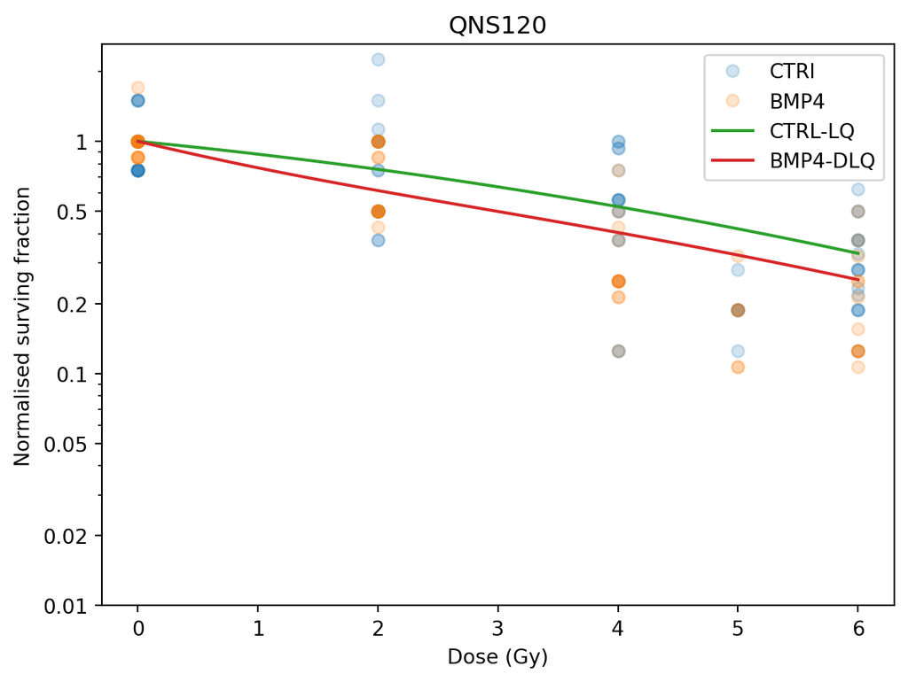

```python
cline = "QNS120"

# Fit the model to the data CTRL case
#popt_ctrl, pcov_ctrl = curve_fit(LQ_model, rt_df[(rt_df["cline"] == cline) & (rt_df["group"] == "CTRL")]["dose"], rt_df[(rt_df["cline"]== cline) & (rt_df["group"] == "CTRL")]["norm_pe"],bounds=([0, 0], [np.inf, np.inf]))

# Fit the model to the data CTRL case with alpha/beta fixed to 10
popt_ctrl_fixed, pcov_ctrl_fixed = curve_fit(LQ_model_fixed_ratio, rt_df[(rt_df["cline"] == cline) & (rt_df["group"] == "CTRL")]["dose"], rt_df[(rt_df["cline"]== cline) & (rt_df["group"] == "CTRL")]["norm_pe"],bounds=([0], [np.inf]))

# Extract the fitted parameters CTRL case
#alpha, beta = popt_ctrl
#alpha = alpha / gamma
#beta = beta / gamma

alpha = popt_ctrl_fixed
alpha = alpha / gamma
beta = alpha / 10

# Function to evaluate DLQ model
def DLQ_model(dose,F):

    return F*np.exp(gamma*(-alpha * dose - beta * dose**2)) + (1-F)*np.exp(-alpha * dose - beta * dose**2)


# Fit the model to the data BMP4 case to get an estimate of F
popt_BMP4, pcov_BMP4 = curve_fit(DLQ_model, rt_df[(rt_df["cline"] == cline) & (rt_df["group"] == "BMP4")]["dose"], rt_df[(rt_df["cline"]== cline) & (rt_df["group"] == "BMP4")]["norm_pe"],bounds=([0], [ 1]))

# Extract the param of interest
F = popt_BMP4
print(f"Fraction of GSC F = {F}")
print(f"Fitted parameters for CTRL case: alpha = {alpha}, beta = {beta}")
print(f"alpha/beta = {alpha/beta}")

plt.plot(rt_df[(rt_df["cline"] == cline) & (rt_df["group"] == "CTRL")]["dose"],rt_df[(rt_df["cline"]== cline) & (rt_df["group"] == "CTRL")]["norm_pe"] , 'o',alpha = 0.2)
plt.plot(rt_df[(rt_df["cline"] == cline) & (rt_df["group"] == "BMP4")]["dose"],rt_df[(rt_df["cline"]== cline) & (rt_df["group"] == "BMP4")]["norm_pe"] , 'o',alpha = 0.2)

doses= np.linspace(0,6,101)
plt.plot(doses,LQ_model(doses,alpha*gamma,beta*gamma))
plt.plot(doses,DLQ_model(doses,F))

plt.legend(["CTRl", "BMP4", "CTRL-LQ", "BMP4-DLQ"])
plt.xlabel("Dose (Gy)")
plt.ylabel("Normalised surving fraction")
plt.yscale('log')
ticks = [0.01,0.02,0.05,0.1,0.2,0.5,1]
ticks_str = list(map(str, ticks)) # Convert each number to a string
plt.yticks(ticks, ticks_str)
plt.title(f"{cline}")

plt.show()
```

## 6.3 QNS108 (Male primary)

```
Fraction of GSC F = [0.9486727]
Fitted parameters for CTRL case: alpha = [1.09968206], beta = [0.10996821]
alpha/beta = [10.]
```

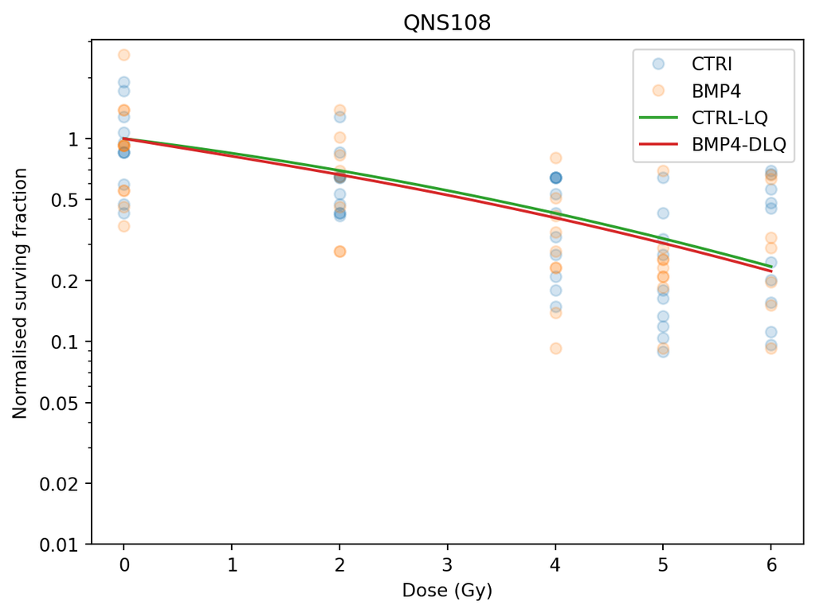

```python
cline = "QNS108"

# Fit the model to the data CTRL case
#popt_ctrl, pcov_ctrl = curve_fit(LQ_model, rt_df[(rt_df["cline"] == cline) & (rt_df["group"] == "CTRL")]["dose"], rt_df[(rt_df["cline"]== cline) & (rt_df["group"] == "CTRL")]["norm_pe"],bounds=([0, 0], [np.inf, np.inf]))

# Fit the model to the data CTRL case with alpha/beta fixed to 10
popt_ctrl_fixed, pcov_ctrl_fixed = curve_fit(LQ_model_fixed_ratio, rt_df[(rt_df["cline"] == cline) & (rt_df["group"] == "CTRL")]["dose"], rt_df[(rt_df["cline"]== cline) & (rt_df["group"] == "CTRL")]["norm_pe"],bounds=([0], [np.inf]))

# Extract the fitted parameters CTRL case
#alpha, beta = popt_ctrl
#alpha = alpha / gamma
#beta = beta / gamma

alpha = popt_ctrl_fixed
alpha = alpha / gamma
beta = alpha / 10

# Function to evaluate DLQ model
def DLQ_model(dose,F):

    return F*np.exp(gamma*(-alpha * dose - beta * dose**2)) + (1-F)*np.exp(-alpha * dose - beta * dose**2)


# Fit the model to the data BMP4 case to get an estimate of F
popt_BMP4, pcov_BMP4 = curve_fit(DLQ_model, rt_df[(rt_df["cline"] == cline) & (rt_df["group"] == "BMP4")]["dose"], rt_df[(rt_df["cline"]== cline) & (rt_df["group"] == "BMP4")]["norm_pe"],bounds=([0], [ 1]))

# Extract the param of interest
F = popt_BMP4
print(f"Fraction of GSC F = {F}")
print(f"Fitted parameters for CTRL case: alpha = {alpha}, beta = {beta}")
print(f"alpha/beta = {alpha/beta}")

plt.plot(rt_df[(rt_df["cline"] == cline) & (rt_df["group"] == "CTRL")]["dose"],rt_df[(rt_df["cline"]== cline) & (rt_df["group"] == "CTRL")]["norm_pe"] , 'o',alpha = 0.2)
plt.plot(rt_df[(rt_df["cline"] == cline) & (rt_df["group"] == "BMP4")]["dose"],rt_df[(rt_df["cline"]== cline) & (rt_df["group"] == "BMP4")]["norm_pe"] , 'o',alpha = 0.2)

doses= np.linspace(0,6,101)
plt.plot(doses,LQ_model(doses,alpha*gamma,beta*gamma))
plt.plot(doses,DLQ_model(doses,F))

plt.legend(["CTRl", "BMP4", "CTRL-LQ", "BMP4-DLQ"])
plt.xlabel("Dose (Gy)")
plt.ylabel("Normalised surving fraction")
plt.yscale('log')
ticks = [0.01,0.02,0.05,0.1,0.2,0.5,1]
ticks_str = list(map(str, ticks)) # Convert each number to a string
plt.yticks(ticks, ticks_str)
plt.title(f"{cline}")

plt.show()
```

## 6.4 QNS315 (Female primary)

```
Fraction of GSC F = [1.]
Fitted parameters for CTRL case: alpha = [0.61142079], beta = [0.06114208]
alpha/beta = [10.]
```

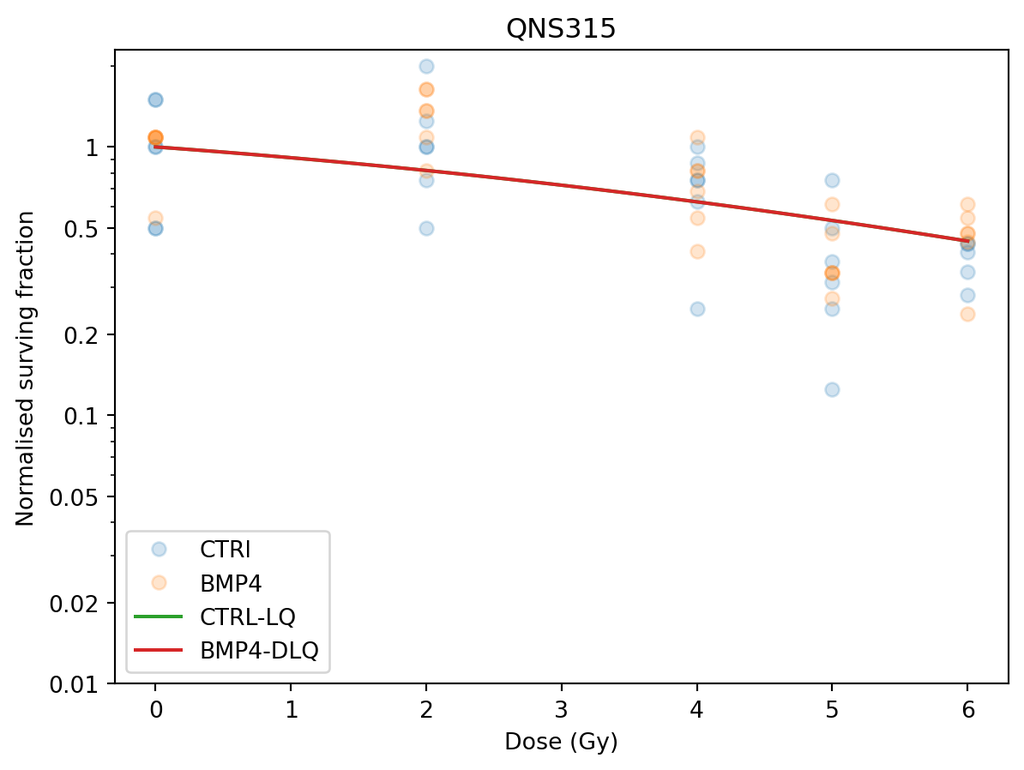

```python
cline = "QNS315"

# Fit the model to the data CTRL case
#popt_ctrl, pcov_ctrl = curve_fit(LQ_model, rt_df[(rt_df["cline"] == cline) & (rt_df["group"] == "CTRL")]["dose"], rt_df[(rt_df["cline"]== cline) & (rt_df["group"] == "CTRL")]["norm_pe"],bounds=([0, 0], [np.inf, np.inf]))

# Fit the model to the data CTRL case with alpha/beta fixed to 10
popt_ctrl_fixed, pcov_ctrl_fixed = curve_fit(LQ_model_fixed_ratio, rt_df[(rt_df["cline"] == cline) & (rt_df["group"] == "CTRL")]["dose"], rt_df[(rt_df["cline"]== cline) & (rt_df["group"] == "CTRL")]["norm_pe"],bounds=([0], [np.inf]))

# Extract the fitted parameters CTRL case
#alpha, beta = popt_ctrl
#alpha = alpha / gamma
#beta = beta / gamma

alpha = popt_ctrl_fixed
alpha = alpha / gamma
beta = alpha / 10

# Function to evaluate DLQ model
def DLQ_model(dose,F):

    return F*np.exp(gamma*(-alpha * dose - beta * dose**2)) + (1-F)*np.exp(-alpha * dose - beta * dose**2)


# Fit the model to the data BMP4 case to get an estimate of F
popt_BMP4, pcov_BMP4 = curve_fit(DLQ_model, rt_df[(rt_df["cline"] == cline) & (rt_df["group"] == "BMP4")]["dose"], rt_df[(rt_df["cline"]== cline) & (rt_df["group"] == "BMP4")]["norm_pe"],bounds=([0], [ 1]))

# Extract the param of interest
F = popt_BMP4
print(f"Fraction of GSC F = {F}")
print(f"Fitted parameters for CTRL case: alpha = {alpha}, beta = {beta}")
print(f"alpha/beta = {alpha/beta}")

plt.plot(rt_df[(rt_df["cline"] == cline) & (rt_df["group"] == "CTRL")]["dose"],rt_df[(rt_df["cline"]== cline) & (rt_df["group"] == "CTRL")]["norm_pe"] , 'o',alpha = 0.2)
plt.plot(rt_df[(rt_df["cline"] == cline) & (rt_df["group"] == "BMP4")]["dose"],rt_df[(rt_df["cline"]== cline) & (rt_df["group"] == "BMP4")]["norm_pe"] , 'o',alpha = 0.2)

doses= np.linspace(0,6,101)
plt.plot(doses,LQ_model(doses,alpha*gamma,beta*gamma))
plt.plot(doses,DLQ_model(doses,F))

plt.legend(["CTRl", "BMP4", "CTRL-LQ", "BMP4-DLQ"])
plt.xlabel("Dose (Gy)")
plt.ylabel("Normalised surving fraction")
plt.yscale('log')
ticks = [0.01,0.02,0.05,0.1,0.2,0.5,1]
ticks_str = list(map(str, ticks)) # Convert each number to a string
plt.yticks(ticks, ticks_str)
plt.title(f"{cline}")

plt.show()
```

## 6.5 QNS657 (Female primary)

```
Fraction of GSC F = [0.70651087]
Fitted parameters for CTRL case: alpha = [0.75426804], beta = [0.0754268]
alpha/beta = [10.]
```

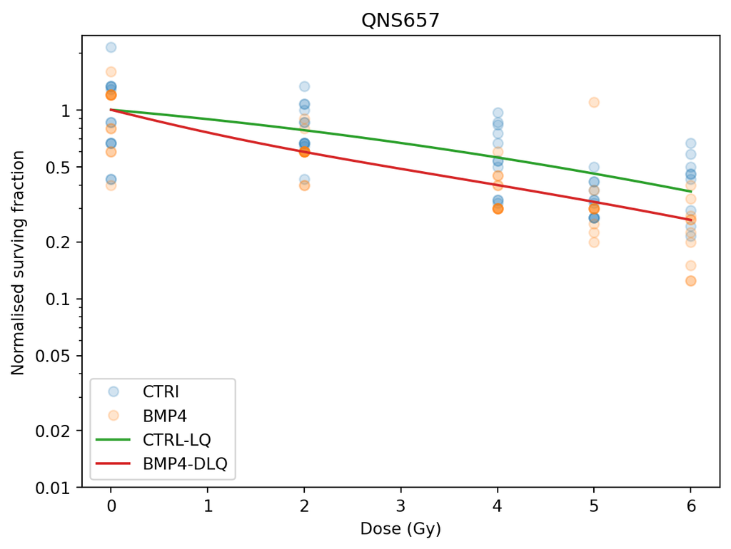

```python
cline = "QNS657"

# Fit the model to the data CTRL case
#popt_ctrl, pcov_ctrl = curve_fit(LQ_model, rt_df[(rt_df["cline"] == cline) & (rt_df["group"] == "CTRL")]["dose"], rt_df[(rt_df["cline"]== cline) & (rt_df["group"] == "CTRL")]["norm_pe"],bounds=([0, 0], [np.inf, np.inf]))

# Fit the model to the data CTRL case with alpha/beta fixed to 10
popt_ctrl_fixed, pcov_ctrl_fixed = curve_fit(LQ_model_fixed_ratio, rt_df[(rt_df["cline"] == cline) & (rt_df["group"] == "CTRL")]["dose"], rt_df[(rt_df["cline"]== cline) & (rt_df["group"] == "CTRL")]["norm_pe"],bounds=([0], [np.inf]))

# Extract the fitted parameters CTRL case
#alpha, beta = popt_ctrl
#alpha = alpha / gamma
#beta = beta / gamma

alpha = popt_ctrl_fixed
alpha = alpha / gamma
beta = alpha / 10

# Function to evaluate DLQ model
def DLQ_model(dose,F):

    return F*np.exp(gamma*(-alpha * dose - beta * dose**2)) + (1-F)*np.exp(-alpha * dose - beta * dose**2)


# Fit the model to the data BMP4 case to get an estimate of F
popt_BMP4, pcov_BMP4 = curve_fit(DLQ_model, rt_df[(rt_df["cline"] == cline) & (rt_df["group"] == "BMP4")]["dose"], rt_df[(rt_df["cline"]== cline) & (rt_df["group"] == "BMP4")]["norm_pe"],bounds=([0], [ 1]))

# Extract the param of interest
F = popt_BMP4
print(f"Fraction of GSC F = {F}")
print(f"Fitted parameters for CTRL case: alpha = {alpha}, beta = {beta}")
print(f"alpha/beta = {alpha/beta}")

plt.plot(rt_df[(rt_df["cline"] == cline) & (rt_df["group"] == "CTRL")]["dose"],rt_df[(rt_df["cline"]== cline) & (rt_df["group"] == "CTRL")]["norm_pe"] , 'o',alpha = 0.2)
plt.plot(rt_df[(rt_df["cline"] == cline) & (rt_df["group"] == "BMP4")]["dose"],rt_df[(rt_df["cline"]== cline) & (rt_df["group"] == "BMP4")]["norm_pe"] , 'o',alpha = 0.2)

doses= np.linspace(0,6,101)
plt.plot(doses,LQ_model(doses,alpha*gamma,beta*gamma))
plt.plot(doses,DLQ_model(doses,F))

plt.legend(["CTRl", "BMP4", "CTRL-LQ", "BMP4-DLQ"])
plt.xlabel("Dose (Gy)")
plt.ylabel("Normalised surving fraction")
plt.yscale('log')
ticks = [0.01,0.02,0.05,0.1,0.2,0.5,1]
ticks_str = list(map(str, ticks)) # Convert each number to a string
plt.yticks(ticks, ticks_str)
plt.title(f"{cline}")

plt.show()
```